# **Emergency Call Prediction in the City of Virginia Beach**

## Rmarkdown Direction

### **1.0 Setup the Working Environment**

### **2.0 Regression**

### **3.0 Data Validation**

### **4.0 Visualization**

### **5.0 Goodness of Fit Model**

### **6.0 Goodness of Fit Test**

### **Final Conclusion and Discussion**

### Basic Assignment Introduction

##### 1.0 Setup the work package and working directory

```r
knitr::opts_chunk$set(echo = TRUE)

library(dplyr)
library(tidyverse)
library(sf)
library(caret)
library(AppliedPredictiveModeling)
library(pscl)
library(e1071)
library(lubridate)
```

##### Define the map frame

```r
pallete4_10_colors <- c("#E8DB4C","#E2B645","#DC923E","#D66D37","#D14931","#AF483E","#8D474B","#6B4758","#494665","#274672")

mapTheme <- function(base_size = 12) {
  theme(
    text = element_text( color = "black"),
    plot.title = element_text(size = 14,colour = "black"),
    plot.subtitle=element_text(face="italic"),
    plot.caption=element_text(hjust=0),
    axis.ticks = element_blank(),
    panel.background = element_rect("darkgrey"),
    axis.title = element_blank(),
    axis.text = element_blank(),
    axis.title.x = element_blank(),
    axis.title.y = element_blank(),
    panel.grid.major = element_line("darkgrey"),
    panel.grid.minor = element_line("darkgrey"),
    panel.border = element_rect(colour = "black", fill=NA, size=2)
  )
}
```

##### Data Preparation

After downloading the data from the open source online, we put the data into the Excel and then ArcGIS to do the data cleaning before importing the data into R. in the Excel, we choose the emergency calls records from 12-01 00:00:00 to 12-21 23:59:59; then import the data to ArcGIS for displaying the data’s X and Y coordinate. We removed the data that is not belonging to the processing extent. Via applying the spatial join, we create field for the emergency point that based on the date of the emergency point, and in this step, we get the emergency data(thefinaldatanewSAT.csv) that is ready to put into the R. #####extract the day and hour from the raw date

```r
emsdata<- read.csv("thefinaldatanewSAT.csv")
emsdata$Call_Date <-mdy_hms(emsdata$Call_Date)
emsdata$day<-day(emsdata$Call_Date)
emsdata$hour<-hour(emsdata$Call_Date)
```

#### 1.1 Group the emsdata by TRACT,DAY AND HOUR.

Count the number of emergency happened in the specific day and hour, constructing the time series for 3 weeks and merge to get the fulldataset

```r
emsdata<- emsdata %>%
  group_by(TRACT,day, hour)  %>%
  summarize(
    X...callID = n()
  )
colnames(emsdata)=c("TRACT","day","hour","callnumber")
hourseries<-data.frame(hour=seq(0:23)-1)
dayforthreeweek<-data.frame(day=seq(1:21))
thetimeseries<- merge(hourseries,dayforthreeweek,all=TRUE)
```

#### 1.2Construct the tract data(only contains the tract value)

We merge the timeseries and the cleaned data to get the full data( every day every hour every tracts). The tract will be our reserach group and ourlater’s data procession will base on it. We then merged the tract information into the EMS data.

#### 1.3.1Now we are going to add the weather data into the dataset.

When checking the weather data we found that there are only 503 rows.which means there is a missing data for 1 hour. For the solution, we add the missing day’s data by estimating its neighbor’s value. Then we extract the weather data from 2016-12-01 to 2016 12-06, call it weather1

```r
#Loading the weather data from 2016-12-01 to 2016-12-06
library(doParallel)
library(foreach)
library(lubridate)
weather.data <- data.frame(date=seq(ymd_hms("2016-12-01 00:00:00"),ymd_hms("2016-12-06 23:59:59"),by="hour"))
cl <- makeCluster(2)
registerDoParallel(cl)
results <- foreach(i=0:7,.packages="lubridate") %dopar%{
  # paste together the URL
  url.text <- paste("http://www.wunderground.com/history/airport/KNTU/",
                    year(weather.data$date[i*24+1]),"/",
                    month(weather.data$date[i*24+1]),"/",
                    day(weather.data$date[i*24+1]),"/",
                    "DailyHistory.html",
                    sep="")
  # read in the webpage
  a <- scan(url.text,what="",sep="\n")

  # search for hourly data
  i <- grep("56 (A|P)M</td>",a)

  # temperature
  temp <- as.numeric(gsub("(<[^>]*>|&[^;]*;|[ F])","",a[i+2]))

  # precipitation
  preci <- as.numeric(gsub("(<[^>]*>|&[^;]*;|[ in]|\\t)","",a[i+25]))
  # NA to 0
  preci[is.na(preci)] <- 0

  return(cbind(temp,preci))
}
results <- do.call(rbind,results)
stopCluster(cl)

weather.data$temperature <- results[,1]
weather.data$precipitation <- results[,2]
write.csv(weather.data, "weatherfirst7days.csv")
```

#### 1.3.2 get the weather from 2016-12-07 01:00:00 to 2016-12-21 23:59:59

```r
weather.data <- data.frame(date=seq(ymd_hms("2016-12-07 01:00:00"),ymd_hms("2016-12-21 23:59:59"),by="hour"))
cl <- makeCluster(2)
registerDoParallel(cl)
results <- foreach(i=0:15,.packages="lubridate") %dopar%{
  # paste together the URL
  url.text <- paste("http://www.wunderground.com/history/airport/KNTU/",
                    year(weather.data$date[i*24+1]),"/",
                    month(weather.data$date[i*24+1]),"/",
                    day(weather.data$date[i*24+1]),"/",
                    "DailyHistory.html",
                    sep="")
  # read in the webpage
  a <- scan(url.text,what="",sep="\n")

  # search for hourly data
  i <- grep("56 (A|P)M</td>",a)

  # temperature
  temp <- as.numeric(gsub("(<[^>]*>|&[^;]*;|[ F])","",a[i+2]))

  # precipitation
  preci <- as.numeric(gsub("(<[^>]*>|&[^;]*;|[ in]|\\t)","",a[i+25]))
  # NA to 0
  preci[is.na(preci)] <- 0

  return(cbind(temp,preci))
}
results <- do.call(rbind,results)
stopCluster(cl)

weather.data$temperature <- results[,1]
weather.data$precipitation <- results[,2]
write.csv(weather.data, "weatherlast14days.csv")
```

#### 1.3.3 Using the excel to add the temperature for the missing data (2016-12-07 00:00:00)

load the weather data

```r
weather<- read.csv("weatherfinal.csv")
weather<-weather[,c(-1)]
names(weather)
```

```
## [1] "temperature" "day"         "hour"
```

```r
thedatainR<-merge(thedatainR,weather,by.x=c("day","hour"),by.y=c("day","hour"))
```

#### 1.4 add the time lag into the dataset

```r
thedatainR$lag.hour<-lag(thedatainR$callnumber,1)
#make the NA to 0
thedatainR[is.na(thedatainR)] <- 0
```

## *2.regression*

Before we start the regression, we want to make some visulization of the emergency calls to better understand the spatial distribution of Virginia Beach’s EMS Call. In this section, we mapped the history data of VB’s EMS call results

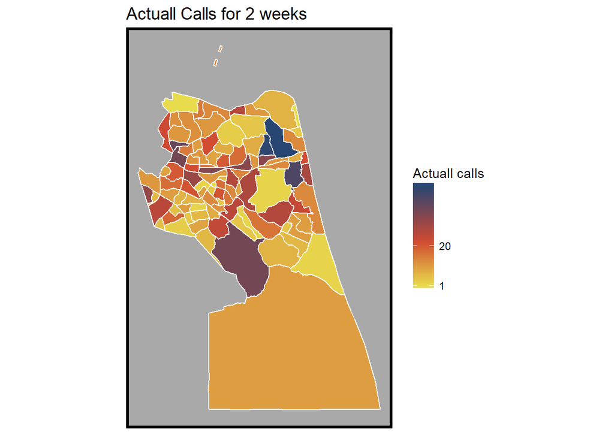

```r
# the actuall calls for 2 weeks
ggplot() +
  geom_sf(data=CensusMap, aes(fill=CensusMap$Count_2), colour= "white")+
  labs(title= "Actuall Calls for 2 weeks")+
  scale_fill_gradientn(colors = pallete4_10_colors,
                       breaks=c(1,20),
                       name = "Actuall calls")+
  mapTheme()
```

### The actuall calls for 1 weeks

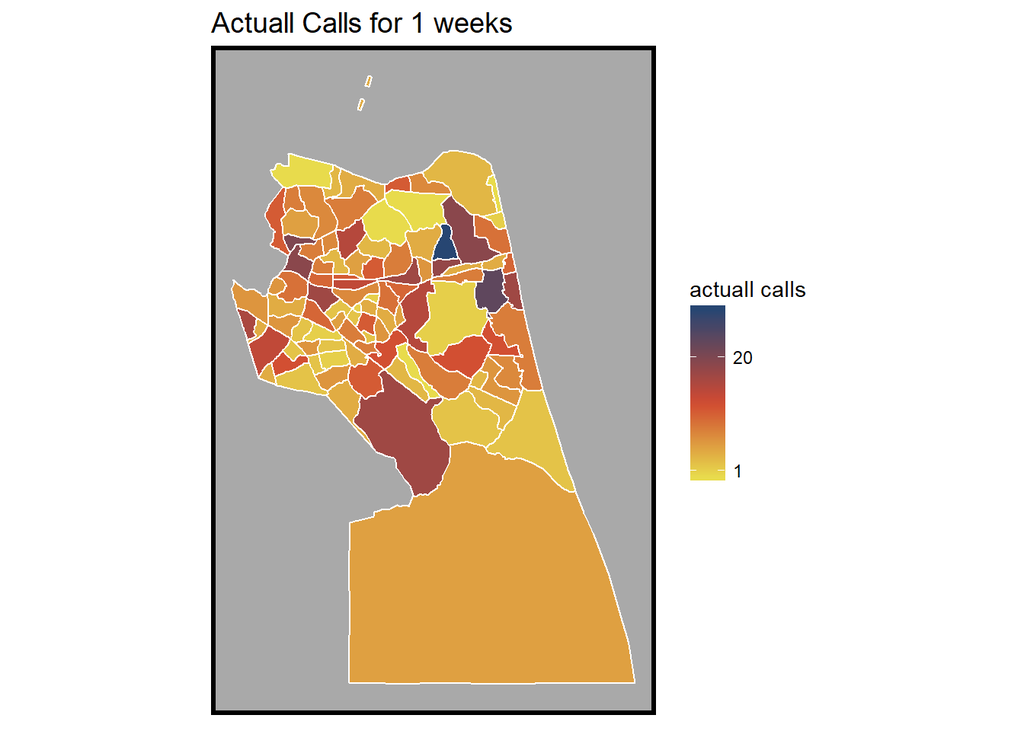

```r
ggplot() +
  geom_sf(data=CensusMap, aes(fill=CensusMap$Count_1), colour= "white")+
  labs(title= "Actuall Calls for 1 weeks")+
  scale_fill_gradientn(colors = pallete4_10_colors,
                       breaks=c(1,20),
                       name = "actuall calls")+
  mapTheme()
```

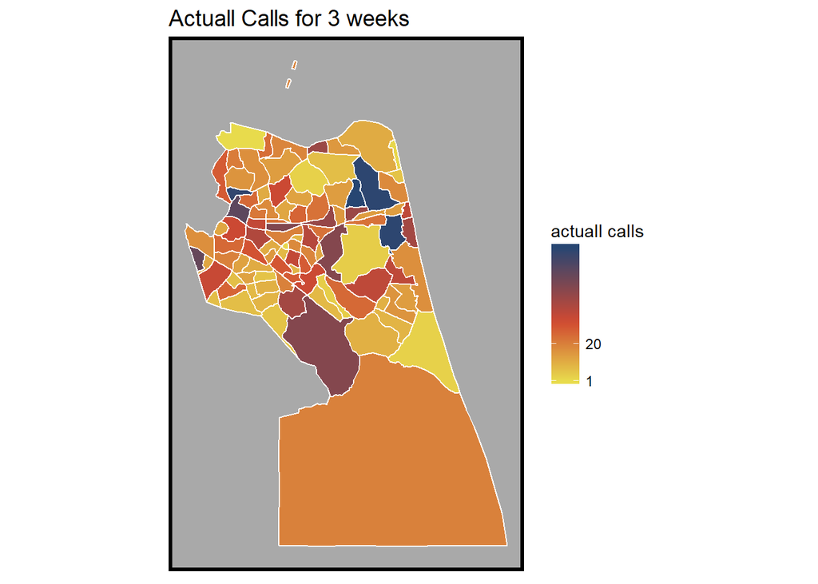

```r
# The actuall calls for 3 weeks
ggplot() +
  geom_sf(data=CensusMap, aes(fill=CensusMap$Count_), colour= "white")+
  labs(title= "Actuall Calls for 3 weeks")+
  scale_fill_gradientn(colors = pallete4_10_colors,
                       breaks=c(1,20),
                       name = "actuall calls")+
  mapTheme()
```

## 2.1 regression model

Now since we already have the regression data(thedatainR), we will apply it to the regression. first, we need to mutate the category variables into factor. We then creart a histogram to summarize the data.

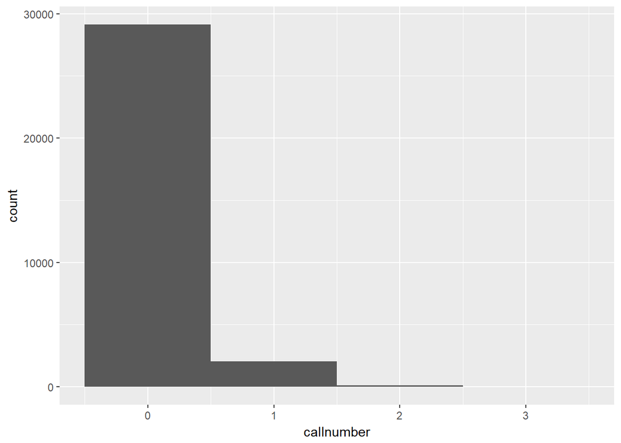

```r
thedatainR<-
  thedatainR %>%
  mutate(hour = as.factor(hour),
         TRACT = as.factor(TRACT)) %>%
  as.data.frame()
ggplot(data = thedatainR,aes(callnumber))+geom_histogram(binwidth = 1)
```

### 2.2.1The Regression

From the distribution of the dependent variable, that it has skewed distribution, we would like to choose the poisson regression for this assigbment

#### 2.2.2 Standardized coefficients

### Which variable works as the most important predictor?

Because we are not sure if the negative value of the coefficient predictor would make any influence to the regression result, we choose to use the absolute value in here.

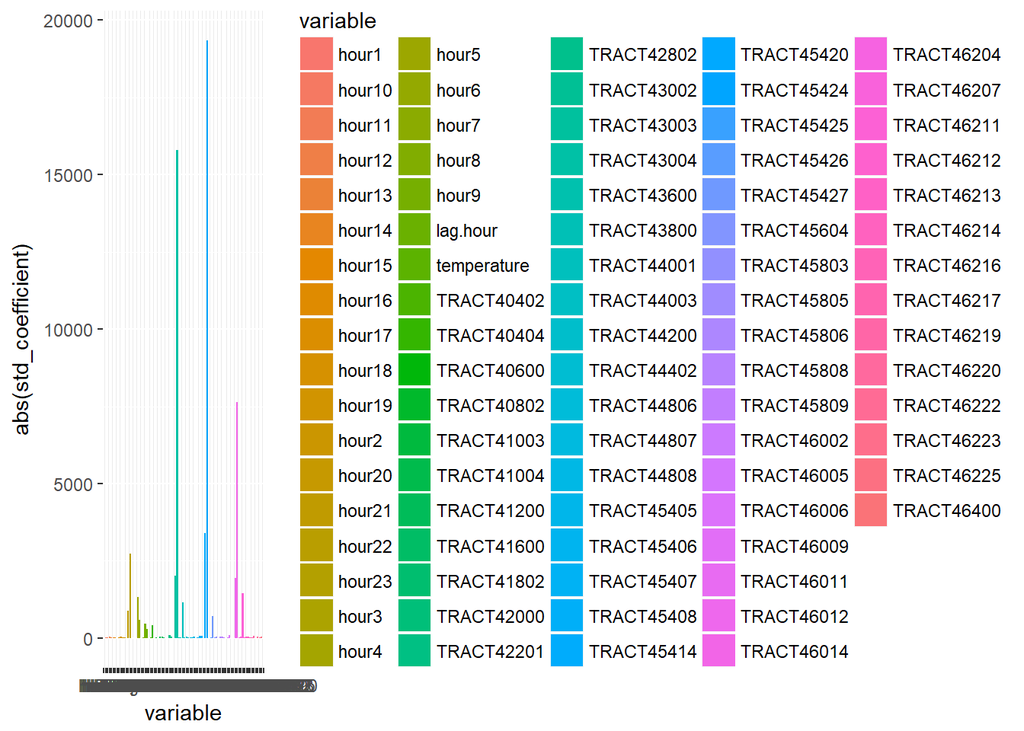

```r
ggplot(standardized, aes(x=variable, y=abs(std_coefficient), fill=variable)) +
  geom_bar(stat="identity")
```

## 3.*Validation*

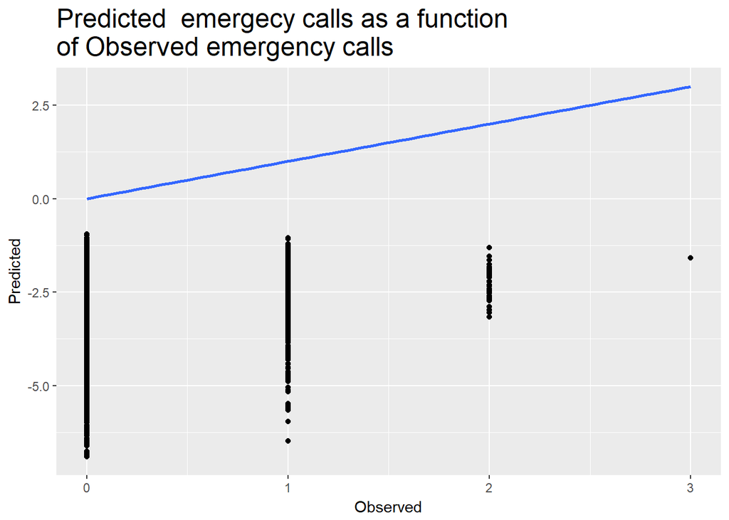

```r
train<-thedatainR[ which(thedatainR$day <14),]
test<-thedatainR[ which(thedatainR$day >13),]
reginRv<-glm(callnumber  ~.,family = "poisson",data = train %>% dplyr::select(-day))
pred2 <- predict(reginRv, test)
regDF2 <- cbind(test$callnumber, pred2)
colnames(regDF2) <- c("Observed", "Predicted")
regDF2 <- as.data.frame(regDF2)
testPred<-cbind(test,pred2)
ggplot() +
  geom_point(data=regDF2, aes(Observed, Predicted)) +
  stat_smooth(data=regDF2, aes(Observed, Observed), method = "lm", se = FALSE, size = 1) +
  labs(title="Predicted  emergecy calls as a function\nof Observed emergency calls") +
  theme(plot.title = element_text(size = 18,colour = "black"))
```

```r
mean(abs(pred2-test$callnumber))
```

```
## [1] 3.135177
```

## 4.*Visualization*

#### 4.1The Predicted Emergency Calls for a Specific Time

#### 4.1.1For the from DEC-12-20-20:00:00 to Dec-12-20-20:59:59

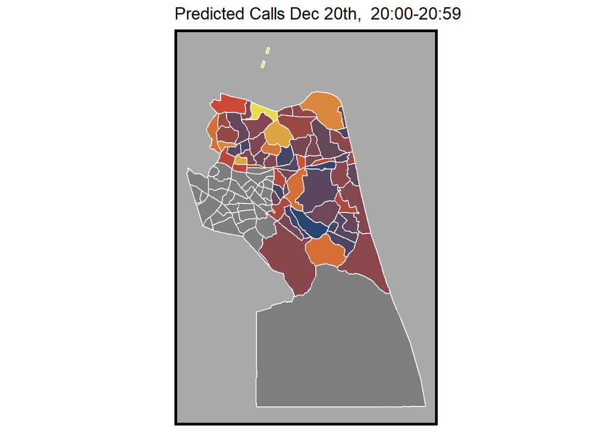

```r
t<-which(testPred$day==20 & testPred$hour == 20)
test20_20<-testPred[t,]
test20_20 <-
  test20_20 %>%
  mutate(
    TRACT = as.numeric(TRACT))
CensusMap <-
  CensusMap %>%
  mutate(
    TRACT = as.numeric(TRACT))
CensusMapNew20_20 <-
  CensusMap %>%
  left_join(test20_20, by=c("TRACT"))
ggplot() +
  geom_sf(data=CensusMapNew20_20, aes(fill=pred2), colour= "white")+
  labs(title= "Predicted Calls Dec 20th,  20:00-20:59")+
  scale_fill_gradientn(colors = pallete4_10_colors,
                       breaks=c(1,20),
                       name = "Predicted calls")+
  mapTheme()
```

### 4.1.2 For the from DEC-12-17-22:00:00 to Dec-12-17-22:59:59

[figure not shown]

```r
t<-which(testPred$day==17 & testPred$hour == 22)
test17_22<-testPred[t,]
test17_22 <-
  test17_22 %>%
  mutate(
    TRACT = as.numeric(TRACT))
CensusMapNew17_22 <-
  CensusMap %>%
  left_join(test17_22, by=c("TRACT"))

ggplot() +
  geom_sf(data=CensusMapNew17_22, aes(fill=pred2), colour= "white")+
  labs(title= "Actual Calls Dec 17th,   22:00-22:59")+
  scale_fill_gradientn(colors = pallete4_10_colors,
                       breaks=c(1,10),
                       name = "Predicted calls")+
  mapTheme()
```

### 4.2 The Actuall Emergency Calls for a Specific Time

#### 4.2.1Selected Date: Actual Calls Dec 20th, 20:00-20:59

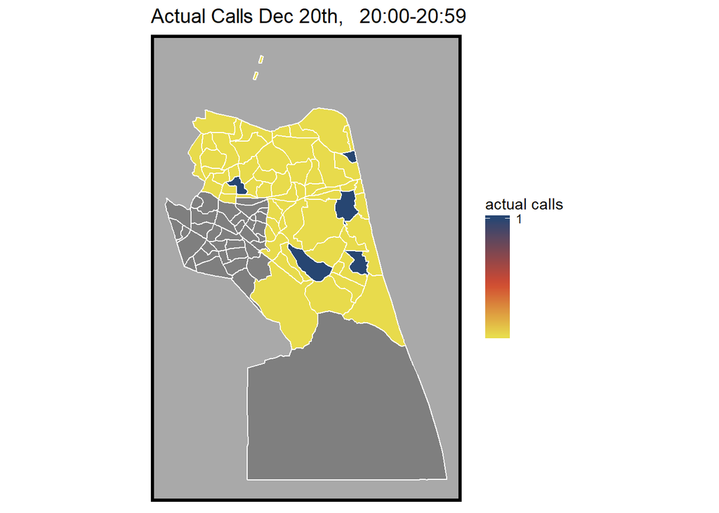

```r
ggplot() +
  geom_sf(data=CensusMapNew20_20, aes(fill=CensusMapNew20_20$callnumber), colour= "white")+
  labs(title= "Actual Calls Dec 20th,   20:00-20:59")+
  scale_fill_gradientn(colors = pallete4_10_colors,
                       breaks=c(1,10),
                       name = "actual calls")+
  mapTheme()
```

#### 4.2.2Actual Calls Dec 17th, 22:00-22:59

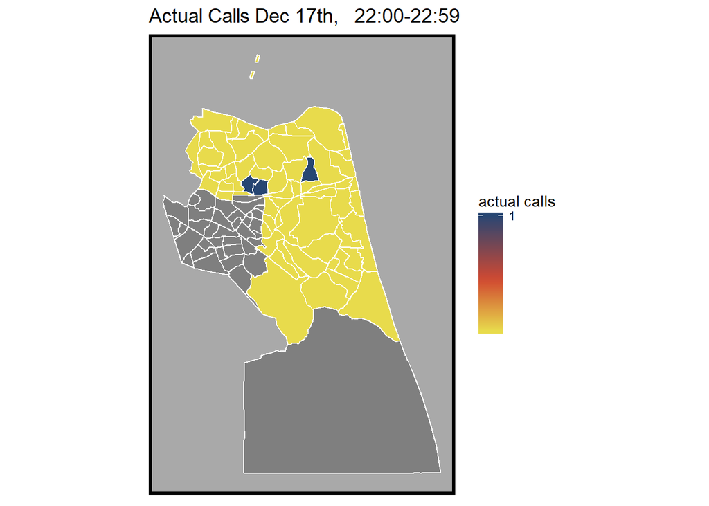

```r
ggplot() +
  geom_sf(data=CensusMapNew17_22, aes(fill=CensusMapNew17_22$callnumber), colour= "white")+
  labs(title= "Actual Calls Dec 17th,   22:00-22:59")+
  scale_fill_gradientn(colors = pallete4_10_colors,
                       breaks=c(1,10),
                       name = "actual calls")+
  mapTheme()
```

## 4.3 The Predicted Emergency Calls for a Specific Location for One Day

#### 4.3.1Predicted EMS: TRACT:045408, TIME: Dec.20th

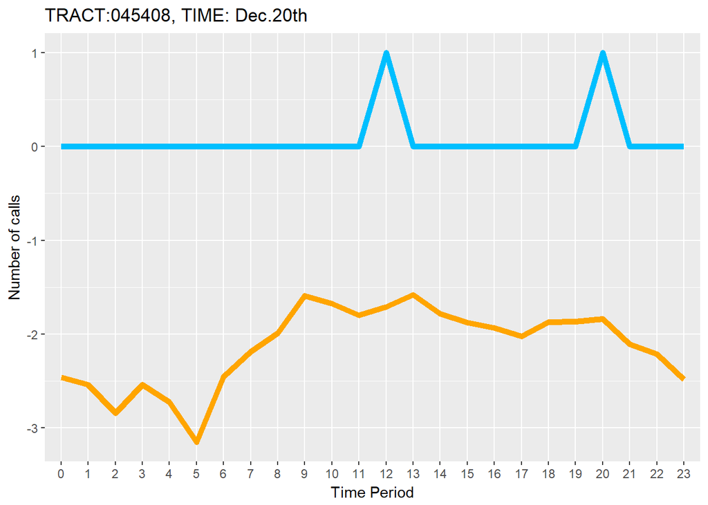

```r
t<-which(testPred$TRACT==045408 & testPred$day == 20)
test045408_20<-testPred[t,]

test045408_20 <-
  test045408_20 %>%
  mutate(
    TRACT = as.numeric(TRACT))
ggplot() +
  geom_line(data = test045408_20, aes(x = hour, y = pred2), color = "orange",group=1, size = 2) +
  geom_line(data = test045408_20, aes(x = hour, y = test045408_20$callnumber), color = "deepskyblue",group=1, size = 2) +
  labs(x = "Time Period", y = "Number of calls", title = "TRACT:045408, TIME: Dec.20th")
```

[figure not shown]

```r
t<-which(testPred$TRACT==041200 & testPred$day == 20)
test041200_20<-testPred[t,]

test041200_20 <-
  test041200_20 %>%
  mutate(
    TRACT = as.numeric(TRACT))
ggplot() +
  geom_line(data = test045408_20, aes(x = hour, y = pred2), color = "orange",group=1, size = 2) +
  geom_line(data = test045408_20, aes(x = hour, y = test045408_20$callnumber), color = "deepskyblue",group=1, size = 2) +
  labs(x = "Time Period", y = "Number of calls", title = "TRACT:041200, TIME: Dec.20th")
```

## 5Goodness of Fit Model

In this section, we test the Risk Terrain Model vs Kernel Density Hotspot to check which model could produce more precise regression result.

We first plot the Absolute Prediction Error Map.

```r
# Meam Absolute Error
mean(abs(reginRv$fitted.values - train$callnumber))
```

```
## [1] 0.1254002
```

```r
mean(abs(pred2-test$callnumber))
```

```
## [1] 3.135177
```

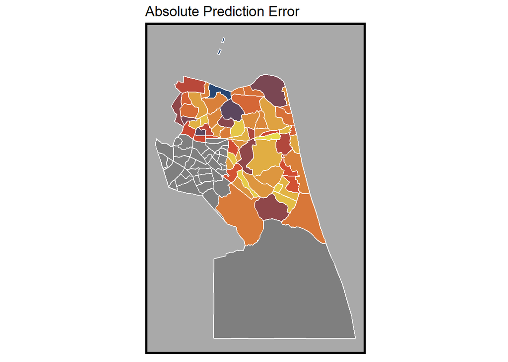

```r
#test the goodness of model by specific time

ggplot() +
  geom_sf(data=CensusMapNew20_20, aes(fill=(abs(CensusMapNew20_20$callnumber- pred2))), colour= "white")+
  labs(title= "Absolute Prediction Error")+
  scale_fill_gradientn(colors = pallete4_10_colors,
                       breaks=c(1,20),
                       name = "Absolute Prediction Error")+
  mapTheme()
```

### MAE

Then we plot the Mean Absolute Error in each area in the City of Virginia Beach

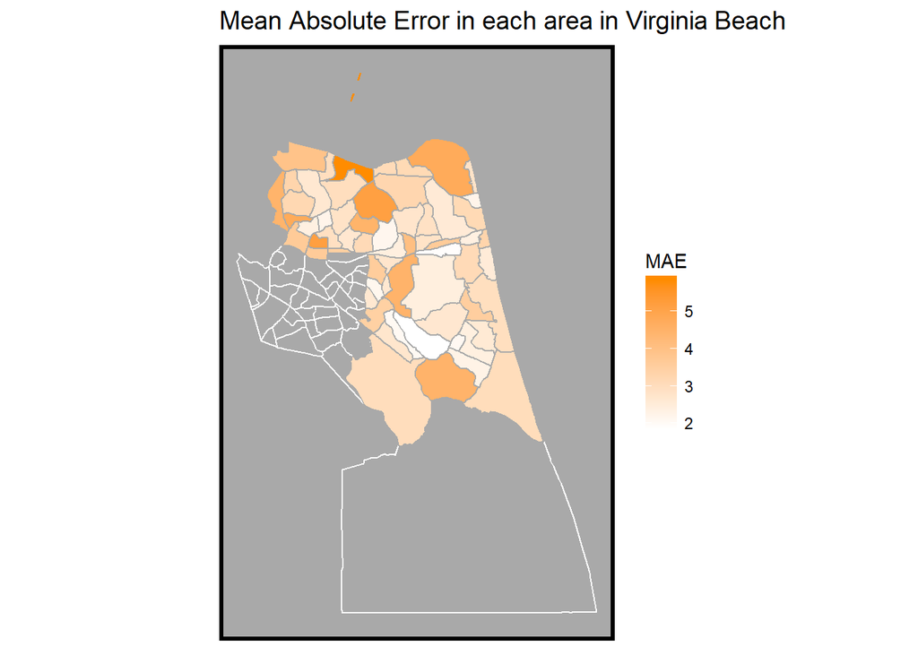

```r
testPred <-
  testPred %>%
  mutate(
    TRACT = as.numeric(TRACT))
reg_Summary <-
  testPred %>%
  group_by(TRACT) %>%
  summarise(MAE = mean(abs(callnumber - pred2), na.rm=TRUE)) %>%
  mutate(Legend="reg") %>%
  left_join(CensusMap, by=c("TRACT")) %>%
  st_sf()

ggplot() +
  geom_sf(data=CensusMap, aes(), fill=NA, colour="white") +
  geom_sf(data=reg_Summary, aes(fill=MAE), colour="darkgrey") +
  labs(title="Mean Absolute Error in each area in Virginia Beach") +
  scale_fill_gradient(low ="white" ,high ="darkorange" )+
  mapTheme()
```

```r
write.csv (x = as.data.frame(testPred), file = "testPred.csv")
```

### *6.Goodness of Fit Test*

Start from this section, we are going to apply the goodness of fit testing for our regression model. We processed the Kernal Density in the ArcGIS (Please see the detailed process description in the Appendix in the end of this RMarkdowwn)

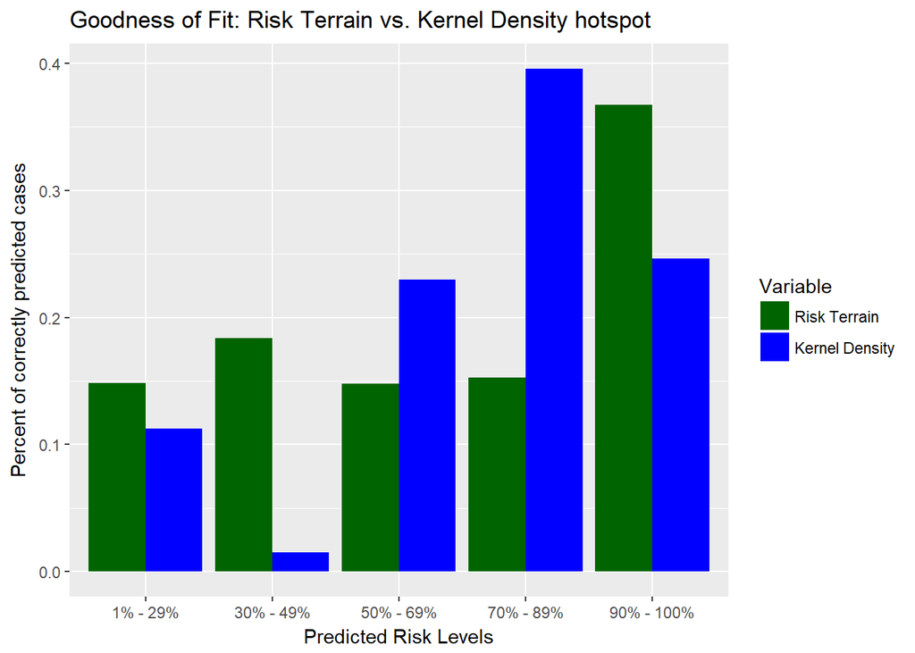

```r
countComparisons <- read.csv("countComparisons.csv")
colnames(countComparisons)=c("X...GRIDCODE","kernelCnt","fittedCnt")
countComparisons <-
  countComparisons %>%
  dplyr::select(X...GRIDCODE, kernelCnt, fittedCnt)

countComparisons <- cbind(
  countComparisons,
  data.frame(Category = c("90% - 100%", "70% - 89%", "50% - 69%", "30% - 49%", "1% - 29%")))

countComparisons <-
  countComparisons %>%
  dplyr::mutate(kernelPct = kernelCnt / sum(kernelCnt),
                fittedPct = fittedCnt / sum(fittedCnt))

countComparisonsLong <-
  countComparisons %>%
  gather(Variable, Value, kernelPct:fittedPct)

ggplot(data=countComparisonsLong, aes(Category,Value)) +
  geom_bar(aes(fill = Variable), position = "dodge", stat="identity") +
  scale_fill_manual(values = c("darkgreen", "blue"),
                    labels=c("Risk Terrain", "Kernel Density")) +
  labs(x= "Predicted Risk Levels",
       y="Percent of correctly predicted cases",
       title= "Goodness of Fit: Risk Terrain vs. Kernel Density hotspot")
```

# Appendix (ArcGIS Kernal Density Work Process)

#### Move your testPred.csv into arcgis.

Join it to the tract shapefile Use polygon to raster to create a raster called fitted. Reclassify fitted to run 1-10. Call this raster fitted_rcl. Reclassify fitted_rcl into a 5 group raster called fitted_rcl2. My breaks are as follows: 90 to 100 = Class 1 70 to 89 = Class 2 50 to 69 = Class 3 30 to 49 = Class 4 1 to 29 = Class 5 # Use raster to polygon to convert fitted_rcl2 into polygons. Call this fittedGroups.shp Spatial join the emergency points to the fittedGroups.shp. Call this fittedgroups_joinPoints.shp. Summarize the groups to get count of emergency by group. In your new .dbf, create a new field called fittedCnt and set it equal to the count of emergency ####Now onto the kernel density comparison.

Run kernel density. Reclass this to run 1- 10. Call this raster kernel_rcl. Reclass again into the same 5 classes you used above, Call this kernel_rcl2. Note that you can pull up your former classifications from the Results tab. Use raster to polygon to convert kernel_rcl2 into polygons. Call this kernelGroups.shp Spatial join the emergency points to the kernelGroups.shp. Call this kernelGroups_joinPoints.shp. Summarize the groups to get count of emergency by group. In your new .dbf, create a new field called kernelCnt and set it equal to the count of emergency. Now to make the comparisons. # Join the kernel density summarized dbf with the comparable dbf from the risk terrain model. Join on the category, 1-5, GRIDCODE. Export as countComparisons.txt Import countComparisons.txt into R. Select out the category field as well as the two fields that describe the count of emergency by both rtm and kernel density. Add a field that changes the category field, GRIDCODE into a sting-based field denoting the percentage range of predictions. Create new fields that represent the count of emergency by category as a percent of all the emergency.